# Intro to RMarkdown

Javier Rojas

June 30, 2017

## Introduction

- R Markdown is a format for writing reproducible, dynamic reports with R. Use it to embed R code and results into slideshows, pdfs, html documents, Word files and more.
- Some advantages of using R Markdown include **coverting your work into accesible formats** with **inputted R code and plots** that are **reproducible**.

## Getting Started

- You can install the R Markdown package as follows:

```r
install.packages("rmarkdown")
```

- To create an R Markdown file, follow these steps in descending order:
  1. In the upper left corner of your current RStudio session, click on **File**
  2. Go to **New File**
  3. Lastly, click on where it says **R Markdown**
- You should see a pop-up screen titled “New R Markdown” where, on the left, you have the different types of R Markdowns, in the top, the **title** and **author** sections that must be filled or modified and at the bottom, the default output format, which indicates whether to transform the R Markdown file into HTML, PDF or Word.
- For the purposes of this tutorial, I created an R Markdown **Document** in **HTML** format, but other options exist. I also provided a **title** and **author** (which is simply my name and last name in this case).
- Any R Markdown file that you create should always look initially similar to this:

[figure not shown]

- At the top of the newly created file, will contain basic information such as the title and author associated with this file. Any modifications to this portion of the file should be made within the hyphen boundaries `---`. **Do NOT touch the hyphen boundaries and always work BELOW the last one**.
- The example text and code that appears below the hyphen boundaries each time you create a new R Markdown can be deleted and replaced by your own text and code.

## Adding Text

- You can start adding text by directly typing on each line:

This tutorial is meant to teach and guide novice R users how to create their own R Markdown file.

- You can create headers by using a pound sign “#” and subheadings with more “#” signs:

```r
### Subheading or #### Smaller Subheading
```

- Add bullet points using a hyphen followed by a space:

```r
- bullet point
```

- Add sub-points using four spaces and a plus sign:

```r
    + sub-point
```

- Add an ordered list by typing the number/letter:

```r
1. first point

    a. sub-sub-point
```

## Formatting Text

- *italics*

```r
*italics* or _italics_
```

- **bold**

```r
**bold** or __bold__
```

- [link](https://www.stu.edu/)

```r
[link](https://www.stu.edu/)
```

- back tickmarks for “code” format: `code here`

```r
`code here`
```

- write equations, such as this $\frac{1}{n} \sum_{i=1}^{n} x_{i}$, as seen on textbooks and on the web by following steps such as these:

```r
$\frac{1}{n} \sum_{i=1}^{n} x_{i}$
```

## Embedding R Code

- R code chunks begin with triple backtick, open brace, r, and then close back tick. They can also include some display options. They also end with a triple backtick.

````r
# ```{r}
#
# ```
````

- In this section, I will be demonstrating how to implement code in your R Markdown. Specifically, I will be showing how to read and work with a .csv file from the web and another from a directory.
- The first example is a .csv file I extracted from my professor Dr. Sanchez’s github repository. The file I extracted is named `HomesForSale.csv`, which, as the name suggests, contains information on homes for sale in California, New Jersey, New York and Pennsylvania regarding their corresponding `price`, `size`, `beds` and `baths`.

```r
# Reading the "Homes for Sale" dataset from Dr. Sanchez's github repository.
suppressMessages(library(RCurl))
suppressMessages(library(tidyverse))
x <- getURL("https://raw.githubusercontent.com/reisanar/datasets/master/HomesForSale.csv")
Homes <- read.csv(text = x)
(Homes <- as_data_frame(Homes))
```

```
## # A tibble: 120 × 5
##     State Price  Size  Beds Baths
##    <fctr> <int> <dbl> <int> <dbl>
## 1      NJ   375   2.1     3   2.5
## 2      NJ   200   0.9     1   1.0
## 3      NJ   599   2.3     5   2.5
## 4      NJ   365   2.1     3   3.0
## 5      NJ   220   2.1     5   2.0
## 6      NJ   250   1.9     4   2.5
## 7      NJ   410   2.2     4   2.5
## 8      NJ   429   2.8     5   2.5
## 9      NJ   325   2.0     3   2.5
## 10     NJ   235   1.1     4   1.0
## # ... with 110 more rows
```

- The summary function can be used to assess the statistical properties of each attribute.

```r
summary(Homes)
```

```
##  State       Price             Size            Beds           Baths
##  CA:30   Min.   :  47.0   Min.   :0.600   Min.   :1.000   Min.   :1.000
##  NJ:30   1st Qu.: 186.2   1st Qu.:1.300   1st Qu.:3.000   1st Qu.:2.000
##  NY:30   Median : 270.0   Median :1.700   Median :3.000   Median :2.000
##  PA:30   Mean   : 479.7   Mean   :2.034   Mean   :3.275   Mean   :2.324
##          3rd Qu.: 483.8   3rd Qu.:2.500   3rd Qu.:4.000   3rd Qu.:2.500
##          Max.   :5900.0   Max.   :6.900   Max.   :7.000   Max.   :8.000
```

- Scatter plots are used to plot two variables against each other (or 3 in the case of 3D plots).

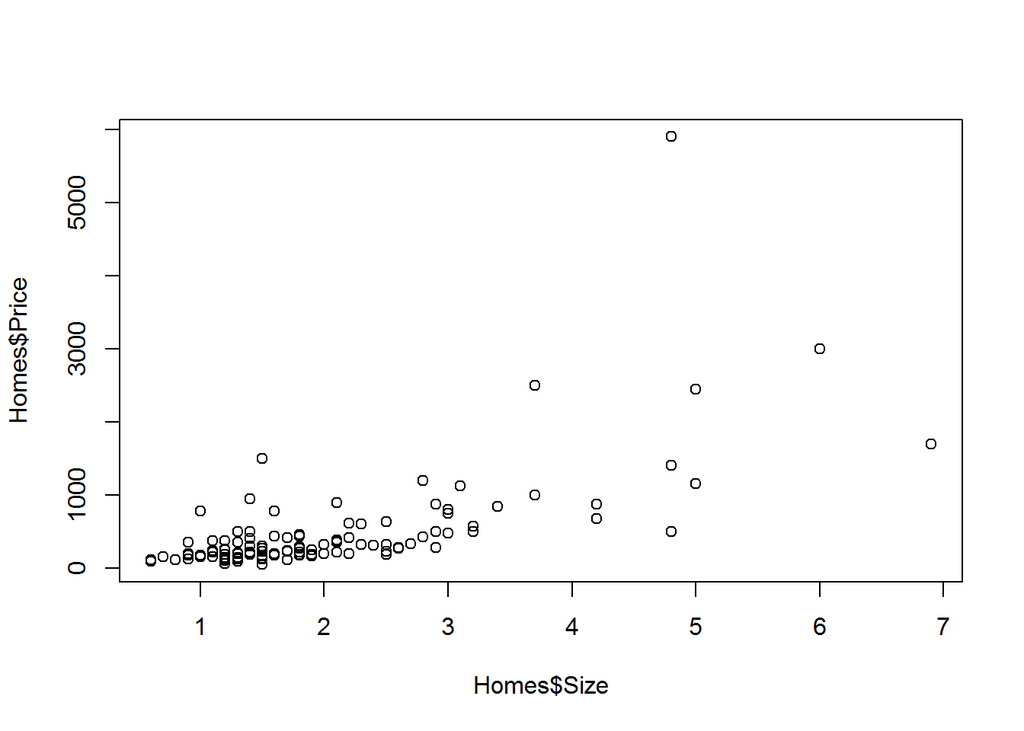

```r
plot(Homes$Size, Homes$Price)
```

- For data sets with only a few attributes, all the pairwise scatter plots may be constructed.

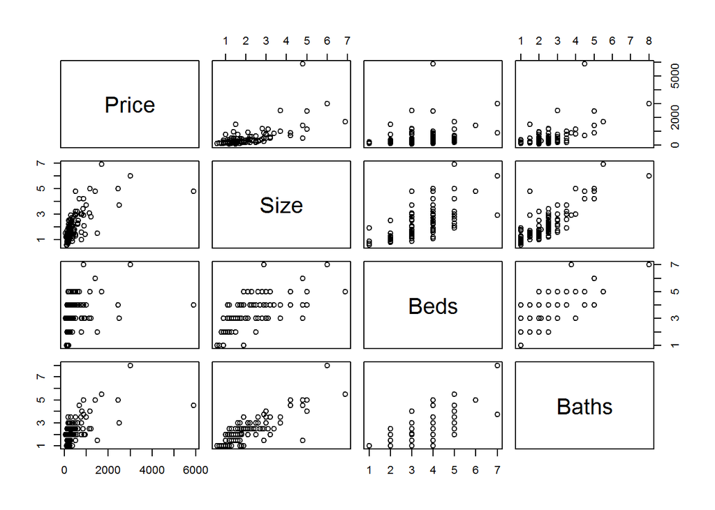

```r
pairs(as.matrix(Homes[,-1]))
```

- Histograms provide you with the frequency in which each data value of a given attribute occurs.

```r
b <- seq(min(Homes$Size), max(Homes$Size), length=10)
b
```

```
##  [1] 0.6 1.3 2.0 2.7 3.4 4.1 4.8 5.5 6.2 6.9
```

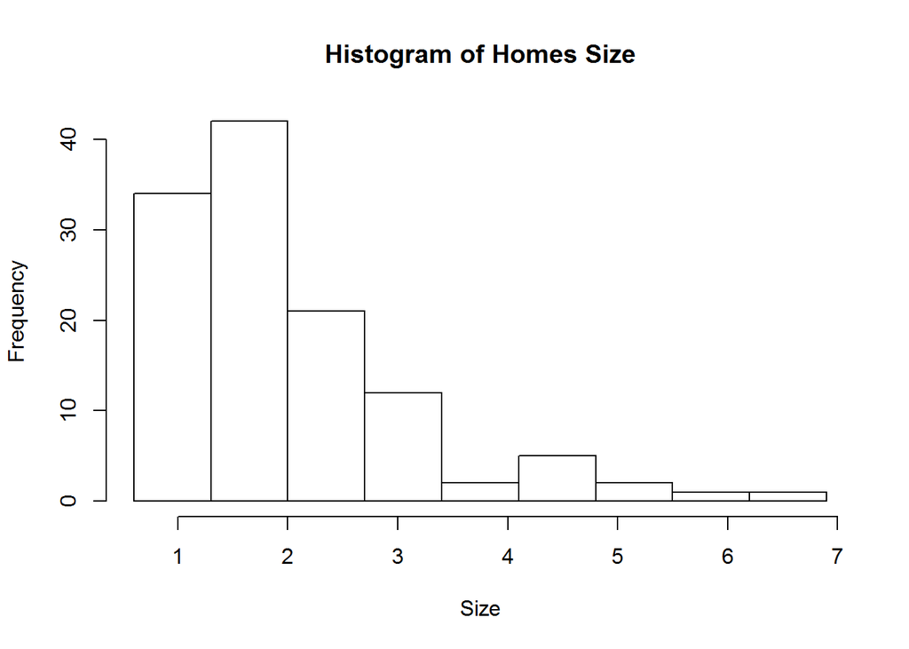

```r
hist(Homes$Size, breaks=b, xlab="Size", main="Histogram of Homes Size")
```

- Density plots can be viewed as smoothed versions of a histogram. We can estimate the density using R’s `density` function.

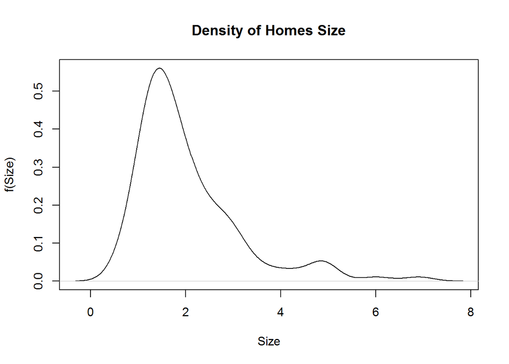

```r
dens.size = density(Homes$Size)
plot(dens.size, ylab = "f(Size)", xlab = "Size", main= "Density of Homes Size")
```

- Box plots are used to compactly show many pieces of information about a variable’s distribution including some summary statistics.

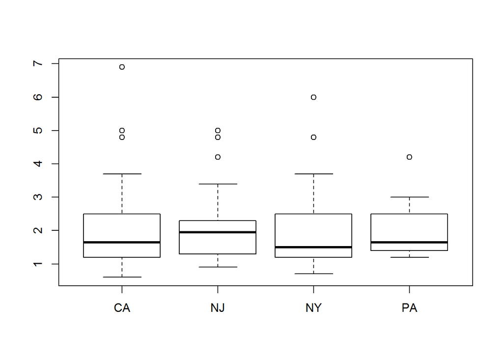

```r
boxplot(Homes$Size ~ Homes$State)
```

- For working with a .csv file from a directory, one of the first steps is to verify what is the current working directory for your current R session. To do so, execute the following command:

```r
getwd()
```

- Upon verifying this, you must be certain whether your .csv file is actually in this working directory. Otherwise, you can expect to receive an error message similar to this:

```r
In file(file, "rt") :
  cannot open file 'FisherIris.csv': No such file or directory
```

- To be sure if it is located in your current working directory, use R’s `dir` function, which will provide you a list of all the files located in your current working directory:

```r
dir()
```

- If not, you can change the current directory to the directory of your choice with R’s `setwd` command. When specifying the desired directory, you can quickly do so by pressing the `tab` button after each forwardslash `/`. This will provide you with a list of options, which can be chosen by scrolling to one in particular and pressing `Enter`. This serves as an auto-complete method of choosing the directory of your liking.

```r
# Example of using the "setwd" command.
setwd("C:/Users/javyr/Documents/")
```

- Once this process is taken care of, you may proceed with reading and working with the .csv file located in the directory you placed it in your computer. In this case, I will use the “Fisher’s Iris” dataset located in my desktop, which consists of **3 classes** of flower types, *setosa*, *virginica* and *versicolor*, along with **4 attributes**, *sepal width*, *sepal length*, *petal width* and *petal length*.
- Afterwards, similar summary statistics and visualizations can be performed with this dataset compared to the previous dataset discussed.

```r
iris <- read.csv("FisherIris.csv")
(iris <- as_data_frame(iris))
```

```
## # A tibble: 150 × 5
##          Type PetalWidth PetalLength SepalWidth SepalLength
##        <fctr>      <int>       <int>      <int>       <int>
## 1      Setosa          2          14         33          50
## 2   Virginica         24          56         31          67
## 3   Virginica         23          51         31          69
## 4      Setosa          2          10         36          46
## 5   Virginica         20          52         30          65
## 6   Virginica         19          51         27          58
## 7  Versicolor         13          45         28          57
## 8  Versicolor         16          47         33          63
## 9   Virginica         17          45         25          49
## 10 Versicolor         14          47         32          70
## # ... with 140 more rows
```

```r
names(iris) = c("iris.type", "petal.width", "petal.length", "sepal.width", "sepal.length")
```

- Summary statistic of `iris` dataset.

```r
summary(iris)
```

```
##       iris.type   petal.width     petal.length    sepal.width
##  Setosa    :50   Min.   : 1.00   Min.   :10.00   Min.   :20.00
##  Versicolor:50   1st Qu.: 3.00   1st Qu.:16.00   1st Qu.:28.00
##  Virginica :50   Median :13.00   Median :44.00   Median :30.00
##                  Mean   :11.93   Mean   :37.79   Mean   :30.55
##                  3rd Qu.:18.00   3rd Qu.:51.00   3rd Qu.:33.00
##                  Max.   :25.00   Max.   :69.00   Max.   :44.00
##   sepal.length
##  Min.   :43.00
##  1st Qu.:51.00
##  Median :58.00
##  Mean   :58.45
##  3rd Qu.:64.00
##  Max.   :79.00
```

- All pairwise scatter plots for `iris` dataset, which also distinguish observations belonging to each type with a different color.

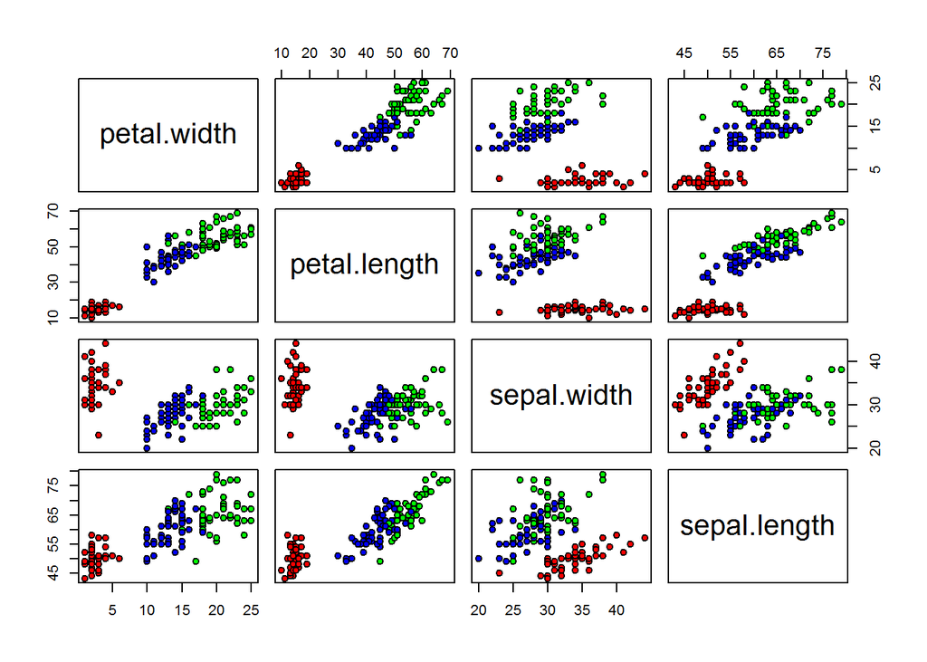

```r
pairs(as.matrix(iris[,-1]), pch=21, bg=c("red", "blue", "green")[unclass(iris$iris.type)])
```

- Histogram visual of `iris's petal.width` not only with equal-width bins, but also with a distinct color, which is “blue”.

```r
b <- seq(min(iris$petal.width), max(iris$petal.width), length=11)
b
```

```
##  [1]  1.0  3.4  5.8  8.2 10.6 13.0 15.4 17.8 20.2 22.6 25.0
```

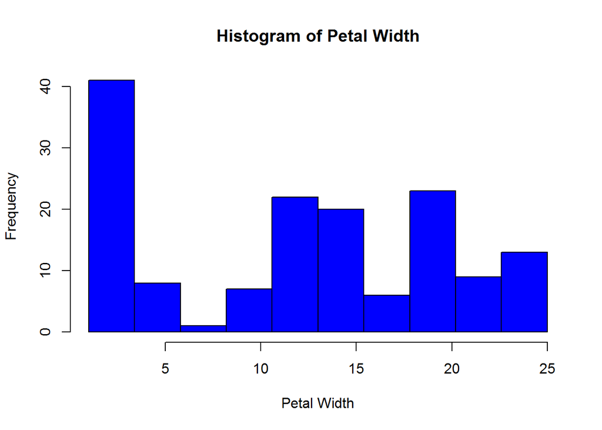

```r
hist(iris$petal.width, breaks=b, col="blue", xlab="Petal Width", main="Histogram of Petal Width")
```

- Density function of `petal.length` for each of the three classes of irises.

```r
density.setosa = density(iris$petal.length[iris$iris.type == "Setosa"])
density.versicolor = density(iris$petal.length[iris$iris.type == "Versicolor"])
density.virginica = density(iris$petal.length[iris$iris.type == "Virginica"])
```

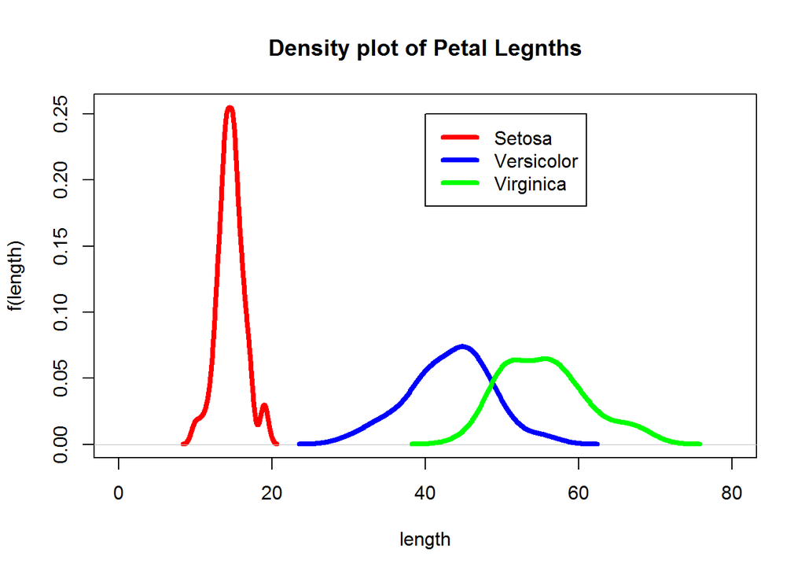

```r
plot(density.setosa, ylab="f(length)", xlab="length", main="Density plot of Petal Legnths", xlim = c(0,80), lwd=4, col="red")
lines(density.versicolor, col="blue", lwd=4)
lines(density.virginica, col="green", lwd=4)
legend(40, 0.25, c("Setosa", "Versicolor", "Virginica"), lwd=rep(4,3), col=c("red", "blue", "green"))
```

- A box plot of each attribute of the iris data set.

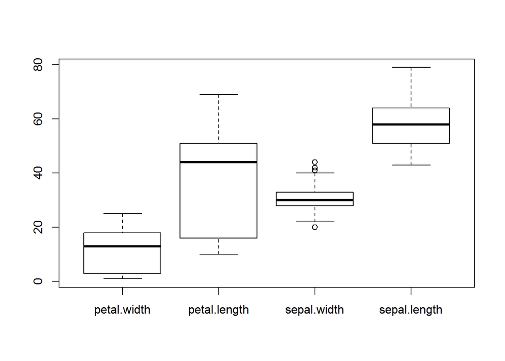

```r
boxplot(iris[,-1])
```

- Finally, to render an R Markdown document into it’s final output format, click on the “Knit” button or type (Ctrl+Shift+K).